# How Certain Statistics Affect NBA Team Success

**By Joel Eckles and Matthew Dovel, Fall 2019**

[figure not shown]

**image from** [link text](https://www.nba.com/)

## Introduction

### Motivation

For this project, we thought it would be interesting to look at how certain statistics affect the overall success of teams in the NBA. From a time where short shorts and converse were the standard, the game of basketball has evolved tremendously over the past 125 years. It is easy to point out key differences in style of play when comparing an NBA game from the 1940s versus a game today, but what about over the past decades? By analyzing team statistics, we hope to dig deeper into how the game of basketball has changed over the course of the last 20 years. Without further ado, lets get into it.

[figure not shown]

#### Key aspects of project:

- Data collection
- Data reorganization and cleaning
- Graph and model relationships between sets of data
- Train our model(s) to predict win percentage
- Comparing stats from 1990s to current stats

### Required Libraries/Tools

The following libraries will be utilized throughout our project. These libraries will aid in the collection, reorganization, and visualization of our data. For more information on each library, check out their documentation.

- `lxml` [docs](https://lxml.de/)
- `html5lib` [docs](https://pypi.org/project/html5lib/)
- `pandas` [docs](https://pandas.pydata.org/)
- `numpy` [docs](https://numpy.org/)
- `matplotlib.pyplot` [docs](https://matplotlib.org/)
- `bs4` [docs](https://pypi.org/project/bs4/)
- `scipy` [docs](https://www.scipy.org/)
- `seaborn` [docs](https://seaborn.pydata.org/)
- `sklearn` [docs](https://scikit-learn.org/stable/)

```python
pip install lxml
```

[output not shown]

```python
pip install html5lib
```

```
     |████████████████████████████████| 122kB 1.1MB/s eta 0:00:01
```

```python
import pandas as pd # used to store data
import numpy as np # used to manipulate data
import matplotlib.pyplot as plt # used to visualize data
from bs4 import BeautifulSoup # used to scrape data from html page
from scipy import stats # used for data anaylsis
import seaborn as sns # used to visual analysis
from sklearn.linear_model import LinearRegression # standard linear regresion
from sklearn.metrics import mean_squared_error # mean squared error for interpreting model
from sklearn.model_selection import train_test_split # used to train model
from sklearn.model_selection import cross_val_score # used to test optimality of our model
```

## Part 1: Data Curation

The first step is to collect the data we will be analyzing. For this we used [team data](https://stats.nba.com/teams/traditional/?sort=W_PCT&dir=-1&Season=2018-19&SeasonType=Regular%20Season) made publicly available by the NBA.

### Data Explanation

We saved the each of the NBA datatables for the most recent 5 years (2014-2018) as HTML files and read each of them into separate pandas Dataframes. The data provided by the NBA only goes back as far as 1996, which works fine in our case as we are only considering data from the past 2 decades. We repeated the same process above for the data from years 1996-2001.

```python
# Read data for years 2014-2018 into separate dataframes.
data2018=pd.DataFrame(pd.read_html("2018-19_NBA_Stats.html",header=[0],flavor='bs4')[0])
data2017=pd.DataFrame(pd.read_html("2017-18_NBA_Stats.html",header=[0],flavor='bs4')[0])
data2016=pd.DataFrame(pd.read_html("2016-17_NBA_Stats.html",header=[0],flavor='bs4')[0])
data2015=pd.DataFrame(pd.read_html("2015-16_NBA_Stats.html",header=[0],flavor='bs4')[0])
data2014=pd.DataFrame(pd.read_html("2014-15_NBA_Stats.html",header=[0],flavor='bs4')[0])

# Read data for years 1996-2001 into separate dataframes.
data1996=pd.DataFrame(pd.read_html("1996-97_NBA_Stats.html",header=[0],flavor='bs4')[0])
data1997=pd.DataFrame(pd.read_html("1997-98_NBA_Stats.html",header=[0],flavor='bs4')[0])
data1998=pd.DataFrame(pd.read_html("1998-99_NBA_Stats.html",header=[0],flavor='bs4')[0])
data1999=pd.DataFrame(pd.read_html("1999-00_NBA_Stats.html",header=[0],flavor='bs4')[0])
data2000=pd.DataFrame(pd.read_html("2000-01_NBA_Stats.html",header=[0],flavor='bs4')[0])

# Print data2018 for reference, all other years should be equivalent
print(data2018.head())
```

```
   Unnamed: 0                   TEAM  GP   W   L   WIN%   MIN    PTS   FGM  \
0           1        Milwaukee Bucks  82  60  22  0.732  48.2  118.1  43.4
1           2        Toronto Raptors  82  58  24  0.707  48.5  114.4  42.2
2           3  Golden State Warriors  82  57  25  0.695  48.3  117.7  44.0
3           4         Denver Nuggets  82  54  28  0.659  48.1  110.7  41.9
4           5        Houston Rockets  82  53  29  0.646  48.4  113.9  39.2

    FGA  ...  DREB RANK  REB RANK  AST RANK  TOV RANK  STL RANK  BLK RANK  \
0  91.1  ...        NaN       NaN       NaN       NaN       NaN       NaN
1  89.1  ...        NaN       NaN       NaN       NaN       NaN       NaN
2  89.8  ...        NaN       NaN       NaN       NaN       NaN       NaN
3  90.0  ...        NaN       NaN       NaN       NaN       NaN       NaN
4  87.4  ...        NaN       NaN       NaN       NaN       NaN       NaN

   BLKA RANK  PF RANK  PFD RANK  +/- RANK
0        NaN      NaN       NaN       NaN
1        NaN      NaN       NaN       NaN
2        NaN      NaN       NaN       NaN
3        NaN      NaN       NaN       NaN
4        NaN      NaN       NaN       NaN

[5 rows x 54 columns]
```

## Part 2: Data Parsing

### Initial Data Cleaing

Now that we have our data, we first need to clean it so that everything is well labeled and ready to work with. From the output above, there are multiple columns in our tables that are filled with NaN values, the first thing we need to do is drop these columns as they will be of no use to us.

[figure not shown]

```python
# Dropping hidden data and data we will not be looking at
data2018.dropna(axis=1, inplace=True)
data2017.dropna(axis=1, inplace=True)
data2016.dropna(axis=1, inplace=True)
data2015.dropna(axis=1, inplace=True)
data2014.dropna(axis=1, inplace=True)

# Repeats the same for years 1996-2001
data1996.dropna(axis=1, inplace=True)
data1997.dropna(axis=1, inplace=True)
data1998.dropna(axis=1, inplace=True)
data1999.dropna(axis=1, inplace=True)
data2000.dropna(axis=1, inplace=True)
```

Eventually we will be combining this data into one table, so add a year column to each table to keep things organized.

```python
# Adding year column to use after combining all the data
data2018['year'] = '2018'
data2017['year'] = '2017'
data2016['year'] = '2016'
data2015['year'] = '2015'
data2014['year'] = '2014'

data2000['year'] = '2000'
data1999['year'] = '1999'
data1998['year'] = '1998'
data1997['year'] = '1997'
data1996['year'] = '1996'
```

At this point, here is what the data for the past 5 years looks like. The data from years 1996-2000 should look the same.

```python
data2018.head()
```

|  | Unnamed: 0 | TEAM | GP | W | L | WIN% | MIN | PTS | FGM | FGA | ... | REB | AST | TOV | STL | BLK | BLKA | PF | PFD | +/- | year |
| --- | --- | --- | --- | --- | --- | --- | --- | --- | --- | --- | --- | --- | --- | --- | --- | --- | --- | --- | --- | --- | --- |
| 0 | 1 | Milwaukee Bucks | 82 | 60 | 22 | 0.732 | 48.2 | 118.1 | 43.4 | 91.1 | ... | 49.7 | 26.0 | 13.9 | 7.5 | 5.9 | 4.8 | 19.6 | 20.2 | 8.9 | 2018 |
| 1 | 2 | Toronto Raptors | 82 | 58 | 24 | 0.707 | 48.5 | 114.4 | 42.2 | 89.1 | ... | 45.2 | 25.4 | 14.0 | 8.3 | 5.3 | 4.5 | 21.0 | 20.5 | 6.1 | 2018 |
| 2 | 3 | Golden State Warriors | 82 | 57 | 25 | 0.695 | 48.3 | 117.7 | 44.0 | 89.8 | ... | 46.2 | 29.4 | 14.3 | 7.6 | 6.4 | 3.6 | 21.4 | 19.5 | 6.5 | 2018 |
| 3 | 4 | Denver Nuggets | 82 | 54 | 28 | 0.659 | 48.1 | 110.7 | 41.9 | 90.0 | ... | 46.4 | 27.4 | 13.4 | 7.7 | 4.4 | 5.0 | 20.0 | 20.4 | 4.0 | 2018 |
| 4 | 5 | Houston Rockets | 82 | 53 | 29 | 0.646 | 48.4 | 113.9 | 39.2 | 87.4 | ... | 42.1 | 21.2 | 13.3 | 8.5 | 4.9 | 4.5 | 22.0 | 20.0 | 4.8 | 2018 |

5 rows × 29 columns

```python
data2017.head()
```

|  | Unnamed: 0 | TEAM | GP | W | L | WIN% | MIN | PTS | FGM | FGA | ... | REB | AST | TOV | STL | BLK | BLKA | PF | PFD | +/- | year |
| --- | --- | --- | --- | --- | --- | --- | --- | --- | --- | --- | --- | --- | --- | --- | --- | --- | --- | --- | --- | --- | --- |
| 0 | 1 | Houston Rockets | 82 | 65 | 17 | 0.793 | 48.2 | 112.4 | 38.7 | 84.2 | ... | 43.5 | 21.5 | 13.8 | 8.5 | 4.8 | 4.4 | 19.5 | 20.4 | 8.5 | 2017 |
| 1 | 2 | Toronto Raptors | 82 | 59 | 23 | 0.720 | 48.4 | 111.7 | 41.3 | 87.4 | ... | 44.0 | 24.3 | 13.4 | 7.6 | 6.1 | 4.9 | 21.7 | 19.9 | 7.8 | 2017 |
| 2 | 3 | Golden State Warriors | 82 | 58 | 24 | 0.707 | 48.1 | 113.5 | 42.8 | 85.1 | ... | 43.5 | 29.3 | 15.4 | 8.0 | 7.5 | 3.7 | 19.6 | 18.5 | 6.0 | 2017 |
| 3 | 4 | Boston Celtics | 82 | 55 | 27 | 0.671 | 48.3 | 104.0 | 38.3 | 85.1 | ... | 44.5 | 22.5 | 14.0 | 7.4 | 4.5 | 4.4 | 19.7 | 19.2 | 3.6 | 2017 |
| 4 | 5 | Philadelphia 76ers | 82 | 52 | 30 | 0.634 | 48.2 | 109.8 | 40.8 | 86.6 | ... | 47.4 | 27.1 | 16.5 | 8.3 | 5.1 | 5.1 | 22.1 | 20.4 | 4.5 | 2017 |

5 rows × 29 columns

```python
data2016.head()
```

|  | Unnamed: 0 | TEAM | GP | W | L | WIN% | MIN | PTS | FGM | FGA | ... | REB | AST | TOV | STL | BLK | BLKA | PF | PFD | +/- | year |
| --- | --- | --- | --- | --- | --- | --- | --- | --- | --- | --- | --- | --- | --- | --- | --- | --- | --- | --- | --- | --- | --- |
| 0 | 1 | Golden State Warriors | 82 | 67 | 15 | 0.817 | 48.2 | 115.9 | 43.1 | 87.1 | ... | 44.4 | 30.4 | 14.8 | 9.6 | 6.8 | 3.8 | 19.3 | 19.4 | 11.6 | 2016 |
| 1 | 2 | San Antonio Spurs | 82 | 61 | 21 | 0.744 | 48.3 | 105.3 | 39.3 | 83.7 | ... | 43.9 | 23.8 | 13.4 | 8.0 | 5.9 | 4.1 | 18.3 | 19.8 | 7.2 | 2016 |
| 2 | 3 | Houston Rockets | 82 | 55 | 27 | 0.671 | 48.2 | 115.3 | 40.3 | 87.2 | ... | 44.4 | 25.2 | 15.1 | 8.2 | 4.3 | 5.0 | 19.9 | 20.4 | 5.8 | 2016 |
| 3 | 4 | Boston Celtics | 82 | 53 | 29 | 0.646 | 48.2 | 108.0 | 38.6 | 85.1 | ... | 42.0 | 25.2 | 13.3 | 7.5 | 4.1 | 5.2 | 20.6 | 20.3 | 2.6 | 2016 |
| 4 | 5 | Cleveland Cavaliers | 82 | 51 | 31 | 0.622 | 48.5 | 110.3 | 39.9 | 84.9 | ... | 43.7 | 22.7 | 13.7 | 6.6 | 4.0 | 4.3 | 18.1 | 20.6 | 3.2 | 2016 |

5 rows × 29 columns

```python
data2015.head()
```

|  | Unnamed: 0 | TEAM | GP | W | L | WIN% | MIN | PTS | FGM | FGA | ... | REB | AST | TOV | STL | BLK | BLKA | PF | PFD | +/- | year |
| --- | --- | --- | --- | --- | --- | --- | --- | --- | --- | --- | --- | --- | --- | --- | --- | --- | --- | --- | --- | --- | --- |
| 0 | 1 | Golden State Warriors | 82 | 73 | 9 | 0.890 | 48.5 | 114.9 | 42.5 | 87.3 | ... | 46.2 | 28.9 | 15.2 | 8.4 | 6.1 | 4.1 | 20.7 | 19.8 | 10.8 | 2015 |
| 1 | 2 | San Antonio Spurs | 82 | 67 | 15 | 0.817 | 48.1 | 103.5 | 40.1 | 82.9 | ... | 43.9 | 24.5 | 13.1 | 8.3 | 5.9 | 3.9 | 17.5 | 19.5 | 10.6 | 2015 |
| 2 | 3 | Cleveland Cavaliers | 82 | 57 | 25 | 0.695 | 48.4 | 104.3 | 38.7 | 84.0 | ... | 44.5 | 22.7 | 13.6 | 6.7 | 3.9 | 4.4 | 20.3 | 20.6 | 6.0 | 2015 |
| 3 | 4 | Toronto Raptors | 82 | 56 | 26 | 0.683 | 48.2 | 102.7 | 36.7 | 81.3 | ... | 43.4 | 18.7 | 13.1 | 7.8 | 5.5 | 5.4 | 19.6 | 22.0 | 4.5 | 2015 |
| 4 | 5 | Oklahoma City Thunder | 82 | 55 | 27 | 0.671 | 48.4 | 110.2 | 41.1 | 86.4 | ... | 48.6 | 23.0 | 15.9 | 7.4 | 5.9 | 4.5 | 20.6 | 20.2 | 7.3 | 2015 |

5 rows × 29 columns

```python
data2014.head()
```

|  | Unnamed: 0 | TEAM | GP | W | L | WIN% | MIN | PTS | FGM | FGA | ... | REB | AST | TOV | STL | BLK | BLKA | PF | PFD | +/- | year |
| --- | --- | --- | --- | --- | --- | --- | --- | --- | --- | --- | --- | --- | --- | --- | --- | --- | --- | --- | --- | --- | --- |
| 0 | 1 | Golden State Warriors | 82 | 67 | 15 | 0.817 | 48.1 | 110.0 | 41.6 | 87.0 | ... | 44.7 | 27.4 | 14.5 | 9.3 | 6.0 | 3.6 | 19.9 | 18.8 | 10.1 | 2014 |
| 1 | 2 | Atlanta Hawks | 82 | 60 | 22 | 0.732 | 48.1 | 102.5 | 38.1 | 81.7 | ... | 40.6 | 25.7 | 14.2 | 9.1 | 4.6 | 4.9 | 17.8 | 19.6 | 5.4 | 2014 |
| 2 | 3 | Houston Rockets | 82 | 56 | 26 | 0.683 | 48.3 | 103.9 | 37.0 | 83.3 | ... | 43.7 | 22.2 | 16.7 | 9.5 | 5.0 | 5.3 | 22.0 | 21.1 | 3.4 | 2014 |
| 3 | 3 | Los Angeles Clippers | 82 | 56 | 26 | 0.683 | 48.1 | 106.7 | 39.4 | 83.3 | ... | 42.6 | 24.8 | 12.3 | 7.8 | 5.0 | 3.0 | 21.3 | 21.5 | 6.6 | 2014 |
| 4 | 5 | Memphis Grizzlies | 82 | 55 | 27 | 0.671 | 48.5 | 98.3 | 37.8 | 82.5 | ... | 42.6 | 21.7 | 13.3 | 8.5 | 4.2 | 5.2 | 19.1 | 20.3 | 3.2 | 2014 |

5 rows × 29 columns

### Combining into One Table

Now that we have cleaned all of our data, we want to combine the 5 tables for years 2014-18 and the tables for years 1996-2001 into their own dataframes so that they can be easily analyzed.

```python
# Combining all data into one dataframe for years 2014-2019
dataCurr = data2018.append(data2017).append(data2016).append(data2015).append(data2014)
dataCurr = dataCurr.drop('Unnamed: 0', axis=1)
print(dataCurr)

# Combining all data into one dataframe for years 1996-2001
dataEarly = data2000.append(data1999).append(data1998).append(data1997).append(data1996)
dataEarly = dataEarly.drop('Unnamed: 0', axis=1)
print(dataEarly)
```

```
                      TEAM  GP   W   L   WIN%   MIN    PTS   FGM   FGA   FG%  \
0          Milwaukee Bucks  82  60  22  0.732  48.2  118.1  43.4  91.1  47.6
1          Toronto Raptors  82  58  24  0.707  48.5  114.4  42.2  89.1  47.4
2    Golden State Warriors  82  57  25  0.695  48.3  117.7  44.0  89.8  49.1
3           Denver Nuggets  82  54  28  0.659  48.1  110.7  41.9  90.0  46.6
4          Houston Rockets  82  53  29  0.646  48.4  113.9  39.2  87.4  44.9
..                     ...  ..  ..  ..    ...   ...    ...   ...   ...   ...
25           Orlando Magic  82  25  57  0.305  48.2   95.7  37.5  82.8  45.3
26      Los Angeles Lakers  82  21  61  0.256  48.6   98.5  37.2  85.6  43.5
27      Philadelphia 76ers  82  18  64  0.220  48.3   92.0  33.7  82.6  40.8
28         New York Knicks  82  17  65  0.207  48.4   91.9  35.1  82.0  42.8
29  Minnesota Timberwolves  82  16  66  0.195  48.3   97.8  36.4  83.2  43.8

    ...   REB   AST   TOV  STL  BLK  BLKA    PF   PFD  +/-  year
0   ...  49.7  26.0  13.9  7.5  5.9   4.8  19.6  20.2  8.9  2018
```

[output cut: 39 more lines]

## Part 3: Data Analysis and Visualization

### Individual Statistic Analysis

#### Mean, median, max, min, and Standard Deviation for each statistic

The statistics that we will be focusing on are points per game (PPG), assists per game (APG), rebounds per game (RPG), blocks per game (BPG), and steals per game (SPG). In order to get a better feel for our data, we first calculate basic statistics of central tendency for each of the individual stats that we will be focusing on. This will also allow us to see how these statistics have changed over the past decade by comparing measures of central tendency from 2014-2018 statistics to those of years 1996-2001. For more information on the importance of summary statistics, check out this informative [resource](https://socratic.org/questions/what-is-the-importance-of-descriptive-statistics).

```python
# Analyze Points Per Game for 2014-2018
meanCurr = np.mean(dataCurr['PTS'])
medianCurr = np.median(dataCurr['PTS'])
maxCurr = np.max(dataCurr['PTS'])
minCurr = np.min(dataCurr['PTS'])
stdevCurr = np.std(dataCurr['PTS'])




# Analyze Points Per Game for 1996-2001
meanEarly = np.mean(dataEarly['PTS'])
medianEarly = np.median(dataEarly['PTS'])
maxEarly = np.max(dataEarly['PTS'])
minEarly = np.min(dataEarly['PTS'])
stdevEarly = np.std(dataEarly['PTS'])

print("Points Per Game Summary Statistics 2014-2019")
print('Mean PPG: ', meanCurr, '\nStd Dev: ', stdevCurr, '\nMedian PPG: ', medianCurr, '\nMin PPG: ', minCurr, '\nMax PPG: ', maxCurr)

print("\nPoints Per Game Summary Statistics 1996-2001")
print('Mean PPG: ', meanEarly, '\nStd Dev: ', stdevEarly, '\nMedian PPG: ', medianEarly, '\nMin PPG: ', minEarly, '\nMax PPG: ', maxEarly)

print("\nt-test p-value: " + str(stats.ttest_ind_from_stats(meanCurr, stdevCurr, len(dataCurr['PTS']), meanEarly, stdevEarly, len(dataEarly['PTS'])).pvalue))
```

```
Points Per Game Summary Statistics 2014-2019
Mean PPG:  105.16199999999999
Std Dev:  5.458347368938697
Median PPG:  104.3
Min PPG:  91.9
Max PPG:  118.1

Points Per Game Summary Statistics 1996-2001
Mean PPG:  95.27034482758621
Std Dev:  4.34546333608188
Median PPG:  95.4
Min PPG:  81.9
Max PPG:  105.5

t-test p-value: 2.9439295560250806e-46
```

```python
# Analyze Assists Per Game for 2014-2018
meanCurr = np.mean(dataCurr['AST'])
medianCurr = np.median(dataCurr['AST'])
maxCurr = np.max(dataCurr['AST'])
minCurr = np.min(dataCurr['AST'])
stdevCurr = np.std(dataCurr['AST'])

# Analyze Assists Per Game for 1996-2001
meanEarly = np.mean(dataEarly['AST'])
medianEarly = np.median(dataEarly['AST'])
maxEarly = np.max(dataEarly['AST'])
minEarly = np.min(dataEarly['AST'])
stdevEarly = np.std(dataEarly['AST'])

print("Assists Per Game Summary Satistics 2014-2019")
print('Mean APG: ', meanCurr, '\nStd Dev: ', stdevCurr, '\nMedian APG: ', medianCurr, '\nMin APG: ', minCurr, '\nMax APG: ', maxCurr)

print("\nAssists Per Game Summary Statistics 1996-2001")
print('Mean APG: ', meanEarly, '\nStd Dev: ', stdevEarly, '\nMedian APG: ', medianEarly, '\nMin APG: ', minEarly, '\nMax APG: ', maxEarly)

print("\nt-test p-value: " + str(stats.ttest_ind_from_stats(meanCurr, stdevCurr, len(dataCurr['AST']), meanEarly, stdevEarly, len(dataEarly['AST'])).pvalue))
```

```
Assists Per Game Summary Satistics 2014-2019
Mean APG:  22.95133333333333
Std Dev:  2.2305077648125073
Median APG:  22.7
Min APG:  18.0
Max APG:  30.4

Assists Per Game Summary Statistics 1996-2001
Mean APG:  21.780689655172413
Std Dev:  2.0516535484814273
Median APG:  21.7
Min APG:  15.6
Max APG:  26.9

t-test p-value: 4.246674461679378e-06
```

```python
# Analyze Rebounds Per Game for 2014-2018
meanCurr = np.mean(dataCurr['REB'])
medianCurr = np.median(dataCurr['REB'])
maxCurr = np.max(dataCurr['REB'])
minCurr = np.min(dataCurr['REB'])
stdevCurr = np.std(dataCurr['REB'])

# Analyze Rebounds Per Game for 1996-2001
meanEarly = np.mean(dataEarly['REB'])
medianEarly = np.median(dataEarly['REB'])
maxEarly = np.max(dataEarly['REB'])
minEarly = np.min(dataEarly['REB'])
stdevEarly = np.std(dataEarly['REB'])

print("Rebounds Per Game Summary Satistics 2014-2019")
print('Mean RPG: ', meanCurr, '\nStd Dev: ', stdevCurr, '\nMedian RPG: ', medianCurr, '\nMin RPG: ', minCurr, '\nMax RPG: ', maxCurr)

print("\nRebounds Per Game Summary Statistics 1996-2001")
print('Mean RPG: ', meanEarly, '\nStd Dev: ', stdevEarly, '\nMedian RPG: ', medianEarly, '\nMin RPG: ', minEarly, '\nMax RPG: ', maxEarly)

print("\nt-test p-value: " + str(stats.ttest_ind_from_stats(meanCurr, stdevCurr, len(dataCurr['REB']), meanEarly, stdevEarly, len(dataEarly['REB'])).pvalue))
```

```
Rebounds Per Game Summary Satistics 2014-2019
Mean RPG:  43.852666666666664
Std Dev:  1.9108705404140343
Median RPG:  43.849999999999994
Min RPG:  38.6
Max RPG:  49.7

Rebounds Per Game Summary Statistics 1996-2001
Mean RPG:  41.93448275862069
Std Dev:  2.0243135681303253
Median RPG:  41.8
Min RPG:  35.8
Max RPG:  47.5

t-test p-value: 2.3690947429664936e-15
```

```python
# Analyze Blocks Per Game for 2014-2018
meanCurr = np.mean(dataCurr['BLK'])
medianCurr = np.median(dataCurr['BLK'])
maxCurr = np.max(dataCurr['BLK'])
minCurr = np.min(dataCurr['BLK'])
stdevCurr = np.std(dataCurr['BLK'])

# Analyze Blocks Per Game for 1996-2001
meanEarly = np.mean(dataEarly['BLK'])
medianEarly = np.median(dataEarly['BLK'])
maxEarly = np.max(dataEarly['BLK'])
minEarly = np.min(dataEarly['BLK'])
stdevEarly = np.std(dataEarly['BLK'])

print("Blocks Per Game Summary Satistics 2014-2019")
print('Mean BPG: ', meanCurr, '\nStd Dev: ', stdevCurr, '\nMedian BPG: ', medianCurr, '\nMin BPG: ', minCurr, '\nMax BPG: ', maxCurr)

print("\nBlocks Per Game Summary Statistics 1996-2001")
print('Mean BPG: ', meanEarly, '\nStd Dev: ', stdevEarly, '\nMedian BPG: ', medianEarly, '\nMin BPG: ', minEarly, '\nMax BPG: ', maxEarly)

print("\nt-test p-value: " + str(stats.ttest_ind_from_stats(meanCurr, stdevCurr, len(dataCurr['BLK']), meanEarly, stdevEarly, len(dataEarly['BLK'])).pvalue))
```

```
Blocks Per Game Summary Satistics 2014-2019
Mean BPG:  4.846666666666667
Std Dev:  0.7522115541669261
Median BPG:  4.8
Min BPG:  2.4
Max BPG:  7.5

Blocks Per Game Summary Statistics 1996-2001
Mean BPG:  5.0731034482758615
Std Dev:  0.9095853676387897
Median BPG:  5.1
Min BPG:  3.3
Max BPG:  8.1

t-test p-value: 0.020307487665789624
```

```python
# Analyze Steals Per Game for 2014-2018
meanCurr = np.mean(dataCurr['STL'])
medianCurr = np.median(dataCurr['STL'])
maxCurr = np.max(dataCurr['STL'])
minCurr = np.min(dataCurr['STL'])
stdevCurr = np.std(dataCurr['STL'])

# Analyze Steals Per Game for 1996-2001
meanEarly = np.mean(dataEarly['STL'])
medianEarly = np.median(dataEarly['STL'])
maxEarly = np.max(dataEarly['STL'])
minEarly = np.min(dataEarly['STL'])
stdevEarly = np.std(dataEarly['STL'])

print("Steals Per Game Summary Satistics 2014-2019")
print('Mean SPG: ', meanCurr, '\nStd Dev: ', stdevCurr, '\nMedian SPG: ', medianCurr, '\nMin SPG: ', minCurr, '\nMax SPG: ', maxCurr)

print("\nSteals Per Game Summary Statistics 1996-2001")
print('Mean SPG: ', meanEarly, '\nStd Dev: ', stdevEarly, '\nMedian SPG: ', medianEarly, '\nMin SPG: ', minEarly, '\nMax SPG: ', maxEarly)

print("\nt-test p-value: " + str(stats.ttest_ind_from_stats(meanCurr, stdevCurr, len(dataCurr['STL']), meanEarly, stdevEarly, len(dataEarly['STL'])).pvalue))
```

```
Steals Per Game Summary Satistics 2014-2019
Mean SPG:  7.723333333333334
Std Dev:  0.8338998074642354
Median SPG:  7.7
Min SPG:  5.7
Max SPG:  10.0

Steals Per Game Summary Statistics 1996-2001
Mean SPG:  8.13655172413793
Std Dev:  0.9792195198290671
Median SPG:  8.0
Min SPG:  6.0
Max SPG:  12.0

t-test p-value: 0.00011626520145435778
```

#### Summary Statistic Analysis

Now that we have the measures of central tendency for each of the statistics for the different time periods, there are a couple things to notice. For one, the mean and the median for each of the statistics seem to line up almost identically, suggesting an overall symmetrical distribution of the data. The most notable difference is that there seems to be 10 more points scored per game when looking at the current data compared to the early data as mean PPG for years 2014-2019 is 105, versus mean PPG for years 1996-2001 being 95 – maybe defense has gotten worse over the most recent years. Other than this, the statistics are fairly similar.

We also ran [t-tests](https://www.investopedia.com/terms/t/t-test.asp) on our data in order to verify our understanding of these statistics and how they have changed between our two time periods. All of our p-values are low, but the points per game p-value sticks out as being basically 0. Having this low of a p-value means that we can conclude that the average number of points scored per game in the 90s is significantly different than the average number of points scored in 2014-2018.

#### Visualize Statistics

Now we want to visualize how certain statistics affect overall team win percentage. To do this, we will create a scatterplot for each of the statistics against win percentage. Since we want to compare data from two time periods, we will append the two different dataframes together to make graphing easier and neater.

[figure not shown]

Before we append the two dataframes, add a column to each dataframe denoting time period.

```python
# Add new column to each dataframe denoting the year
dataCurr['Current?']="Yes"
dataEarly['Current?']="No"
# Append the two dataframes
data = dataCurr.append(dataEarly)
print(data)
```

```
                     TEAM  GP   W   L   WIN%   MIN    PTS   FGM   FGA   FG%  \
0         Milwaukee Bucks  82  60  22  0.732  48.2  118.1  43.4  91.1  47.6
1         Toronto Raptors  82  58  24  0.707  48.5  114.4  42.2  89.1  47.4
2   Golden State Warriors  82  57  25  0.695  48.3  117.7  44.0  89.8  49.1
3          Denver Nuggets  82  54  28  0.659  48.1  110.7  41.9  90.0  46.6
4         Houston Rockets  82  53  29  0.646  48.4  113.9  39.2  87.4  44.9
..                    ...  ..  ..  ..    ...   ...    ...   ...   ...   ...
24     Philadelphia 76ers  82  22  60  0.268  48.2  100.2  36.6  83.5  43.8
25         Denver Nuggets  82  21  61  0.256  48.6   97.8  35.8  81.5  43.9
26      San Antonio Spurs  82  20  62  0.244  48.1   90.5  34.5  77.9  44.2
27         Boston Celtics  82  15  67  0.183  48.5  100.6  37.4  85.0  44.0
28    Vancouver Grizzlies  82  14  68  0.171  48.2   89.2  34.4  78.7  43.7

    ...   AST   TOV  STL  BLK  BLKA    PF   PFD   +/-  year  Current?
0   ...  26.0  13.9  7.5  5.9   4.8  19.6  20.2   8.9  2018       Yes
1   ...  25.4  14.0  8.3  5.3   4.5  21.0  20.5   6.1  2018       Yes
2   ...  29.4  14.3  7.6  6.4   3.6  21.4  19.5   6.5  2018       Yes
3   ...  27.4  13.4  7.7  4.4   5.0  20.0  20.4   4.0  2018       Yes
4   ...  21.2  13.3  8.5  4.9   4.5  22.0  20.0   4.8  2018       Yes
..  ...   ...   ...  ...  ...   ...   ...   ...   ...   ...       ...
24  ...  20.7  17.5  8.3  4.8   6.0  21.1   0.1  -6.5  1996        No
25  ...  23.0  16.6  6.1  5.9   5.5  21.8   0.2  -6.3  1996        No
26  ...  20.3  15.2  7.9  5.3   5.5  21.5   0.2  -7.9  1996        No
27  ...  21.9  16.4  9.9  3.8   6.8  23.4   0.1  -7.3  1996        No
28  ...  22.7  15.9  8.0  5.7   5.6  21.4   0.1 -10.2  1996        No

[295 rows x 29 columns]
```

```
2014-2018 Slope: 0.013248088054119263

1996-2000 Slope: 0.015593680368073685
```

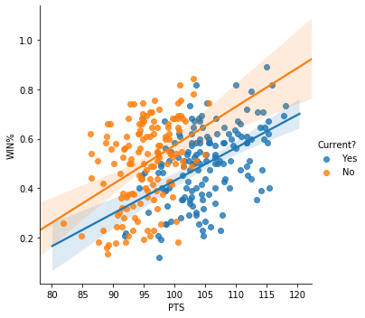

```python
# use seaborn library to plot
g = sns.lmplot(x="PTS", y="WIN%", hue="Current?", data=data)

# Extract the slopes of each line of best fit
slopeCurr, interceptCurr, r_valueCurr, p_valueCurr, std_errCurr = stats.linregress(dataCurr['PTS'], dataCurr['WIN%'])
slopeEarly, interceptEarly, r_valueEarly, p_valueEarly, std_errEarly = stats.linregress(dataEarly['PTS'], dataEarly['WIN%'])

print("2014-2018 Slope: " + str(slopeCurr) + "\n")
print("1996-2000 Slope: " + str(slopeEarly) + "\n")
```

```
2014-2018 Slope: 0.027604586371721387

1996-2000 Slope: 0.03645922335055668
```

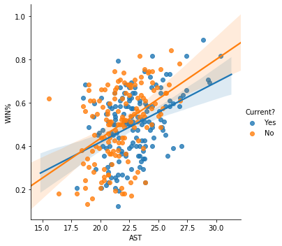

```python
g = sns.lmplot(x="AST", y="WIN%", hue="Current?", data=data)

slopeCurr, interceptCurr, r_valueCurr, p_valueCurr, std_errCurr = stats.linregress(dataCurr['AST'], dataCurr['WIN%'])
slopeEarly, interceptEarly, r_valueEarly, p_valueEarly, std_errEarly = stats.linregress(dataEarly['AST'], dataEarly['WIN%'])

print("2014-2018 Slope: " + str(slopeCurr) + "\n")
print("1996-2000 Slope: " + str(slopeEarly) + "\n")
```

```
2014-2018 Slope: 0.02338941897771698

1996-2000 Slope: 0.01582518930513064
```

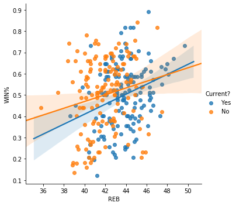

```python
g = sns.lmplot(x="REB", y="WIN%", hue="Current?", data=data)

slopeCurr, interceptCurr, r_valueCurr, p_valueCurr, std_errCurr = stats.linregress(dataCurr['REB'], dataCurr['WIN%'])
slopeEarly, interceptEarly, r_valueEarly, p_valueEarly, std_errEarly = stats.linregress(dataEarly['REB'], dataEarly['WIN%'])

print("2014-2018 Slope: " + str(slopeCurr) + "\n")
print("1996-2000 Slope: " + str(slopeEarly) + "\n")
```

```
2014-2018 Slope: 0.06921828607336428

1996-2000 Slope: 0.01823825204341031
```

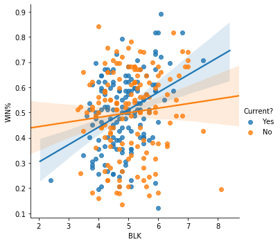

```python
g = sns.lmplot(x="BLK", y="WIN%", hue="Current?", data=data)

slopeCurr, interceptCurr, r_valueCurr, p_valueCurr, std_errCurr = stats.linregress(dataCurr['BLK'], dataCurr['WIN%'])
slopeEarly, interceptEarly, r_valueEarly, p_valueEarly, std_errEarly = stats.linregress(dataEarly['BLK'], dataEarly['WIN%'])

print("2014-2018 Slope: " + str(slopeCurr) + "\n")
print("1996-2000 Slope: " + str(slopeEarly) + "\n")
```

```
2014-2018 Slope: 0.037059295358312656

1996-2000 Slope: 0.007520532969316857
```

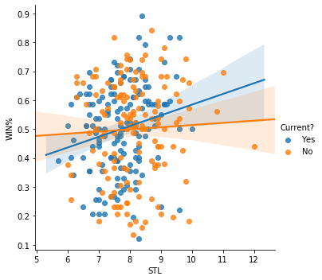

```python
g = sns.lmplot(x="STL", y="WIN%", hue="Current?", data=data)

slopeCurr, interceptCurr, r_valueCurr, p_valueCurr, std_errCurr = stats.linregress(dataCurr['STL'], dataCurr['WIN%'])
slopeEarly, interceptEarly, r_valueEarly, p_valueEarly, std_errEarly = stats.linregress(dataEarly['STL'], dataEarly['WIN%'])

print("2014-2018 Slope: " + str(slopeCurr) + "\n")
print("1996-2000 Slope: " + str(slopeEarly) + "\n")
```

#### Interpreting Scatter Plot Slopes

For each scatter plot, we have printed out the slopes of the regression lines for the plot below it. These slopes can be interpreted as the increase in win percentage for every increase of 1 for the statistic being plotted. As you can see from the first plot, the 2014-2018 slope for win percentage vs. PPG is 0.013. If we scale up the slope a bit, we can say that for an increase of 5 points per game over a season, a teams win percentage is expected to increase by 0.065 ( 0.013 * 5 ). This 6.5% would equate to an extra 5-6 wins in a regular 82 game season.

You can do similar analysis with the other statistics, but there are a few things to consider when looking at these slopes. First is the frequency of the statistic in the sport. When comparing the slopes for blocks per game and points per game, you have to consider tha fact that a block is much less frequent than a point in basketball. So even though the blocks per game slope is much higher, it is much rarer to get 5 extra blocks per game in a season than it is for 5 extra PPG. The second thing to consider is the correlation. We will talk about this more in the next section, but statistics like blocks and steals and much less correlated to win percentage, so they are often worse at predicting the actual change you would see in win percentage if those statistics were affected.

```python
# Extract main statistics that  we care about for the current and past time periods
dataCurrMainStats = pd.concat([dataCurr['WIN%'], dataCurr['PTS'], dataCurr['AST'], dataCurr['REB'], dataCurr['FG%'], dataCurr['3P%'], dataCurr['BLK'], dataCurr['STL']], axis=1)
dataEarlyMainStats = pd.concat([dataEarly['WIN%'], dataEarly['PTS'], dataEarly['AST'], dataEarly['REB'], dataEarly['FG%'], dataEarly['3P%'], dataEarly['BLK'], dataEarly['STL']], axis=1)

print("Correlations for 2014-2018 Stats \n")
print(dataCurrMainStats.corr().iloc[:1])
print("\n")
print("Correlations for 1996-2000 Stats \n")
print(dataEarlyMainStats.corr().iloc[:1])
```

```
Correlations for 2014-2018 Stats

      WIN%       PTS       AST       REB       FG%      3P%      BLK       STL
WIN%   1.0  0.478804  0.407688  0.295933  0.637216  0.58661  0.34475  0.204623


Correlations for 1996-2000 Stats

      WIN%       PTS       AST       REB       FG%       3P%       BLK  \
WIN%   1.0  0.400384  0.441981  0.189286  0.651664  0.372857  0.098021

           STL
WIN%  0.043513
```

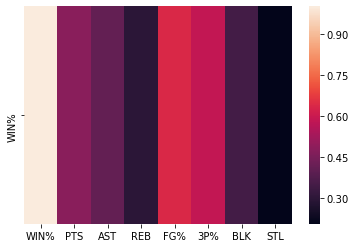

```python
sns.heatmap(dataCurrMainStats.corr().iloc[:1])
```

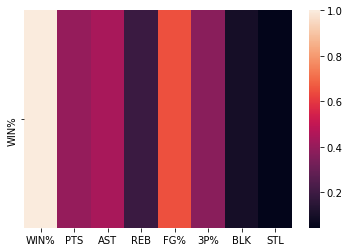

```python
sns.heatmap(dataEarlyMainStats.corr().iloc[:1])
```

#### Interpreting Correlations

The two heatmaps above show how the main statistics were correlated to win percentage from 2014-2018 (first map) and 1996-2000 (second map). The brighter the bar, the more correlated that stat is with win percentage. By comparing these two heatmaps, we can gain some insight on how basketball has changed between these two time periods. One noteable difference is the change in how closely 3-point percentage is correlated to win percentage. In the late 1990s, the correlation between these two was about .37 which is a weak correlation. However, in recent years the two variables seem to be much more correlated showing around a .6 correlation coefficient. Another difference in these time periods is the correlation between PPG and win percentage. In the late 1990s, the two had a .4 correlation coefficient and recently they have shown a slightly higher correlation of around .5. For more information on correlation coefficient and how to interpret it, check out this [resource](https://www.investopedia.com/terms/c/correlationcoefficient.asp).

Overall, these correlation coefficients are not that high because they are just looking at individual statistics. In order to have more accurate representations and predictions, we have to take into account multiple statistics at the same time. In the next section of our project we will use machine learning to train a model of our data which can take statistics (like PPG, APG, RPG, etc.) as input and predict the teams win percentage.

## Part 4: Deeper Analysis and Machine Learning

[figure not shown]

From the analysis part above, we know that certain statistics are more closely correlated with win percentage than others. However, even the most correlated statistics such as, field goal percentage or points per game are not enough alone to accurately predict a team win percentage. As stated above, we need to account for multiple statistics at the same time when making predictions for win percentage, so that is what we will attempt in this section. We will start by doing a linear regression model for each time period and see if the coefficients (weights) that our models give us are significantly different.

### A Predictive Model

The first thing that we would like to do is to put our data for each time period in a training and testing set. As I mentioned above, we found that certain statistics like field goal percentage and 3 point percentage are more correlated with win percentage, so we will include these in our model. This could be problematic as our dataset is not very large.

```python
# X data will represent the inputs that we will get a prediction from
xCurr = np.asarray(dataCurr[['PTS', 'AST', 'REB', 'BLK', 'STL', 'FG%', '3P%']])
# Y data will be used as labels
yCurr = np.asarray(dataCurr['WIN%'])
# splitting data into training and testing sets
xCurr_train, xCurr_test, yCurr_train, yCurr_test = train_test_split(xCurr, yCurr, test_size=0.33, shuffle= True)
```

We will start with a standard linear regression model

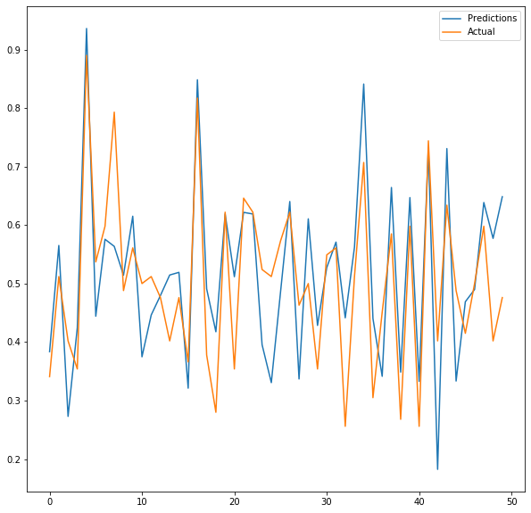

```
Mean Squared Error: 0.010659819115273863
```

```python
regrCurr = LinearRegression()
regrCurr.fit(xCurr_train, yCurr_train)

plt.figure(figsize=(10,10))
plt.plot(regrCurr.predict(xCurr_test), label='Predictions')
plt.plot(yCurr_test, label='Actual')
plt.legend()
plt.show()

print("Mean Squared Error: " + str(mean_squared_error(yCurr_test, regrCurr.predict(xCurr_test))))
```

### Repeating for Early Data

```python
xEarly = np.asarray(dataEarly[['PTS', 'AST', 'REB', 'BLK', 'STL', 'FG%', '3P%']])

yEarly = np.asarray(dataEarly['WIN%'])

xEarly_train, xEarly_test, yEarly_train, yEarly_test = train_test_split(xEarly, yEarly, test_size=0.33, shuffle= True)
```

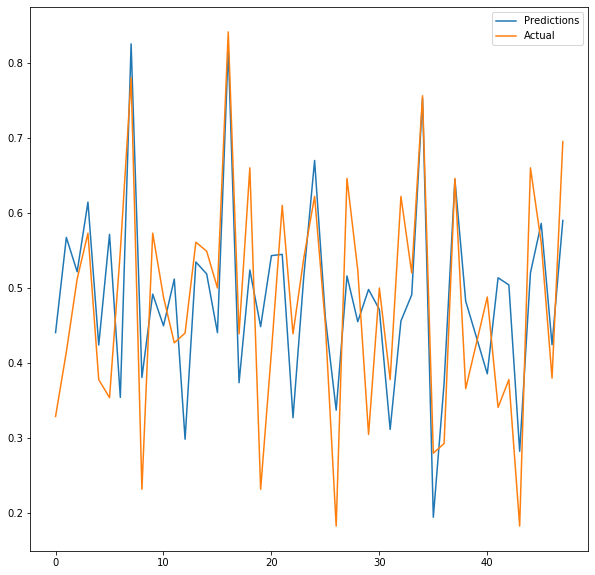

```
Mean Squared Error: 0.011220529359300528
```

```python
regrEarly = LinearRegression()
regrEarly.fit(xEarly_train, yEarly_train)

plt.figure(figsize=(10,10))
plt.plot(regrEarly.predict(xEarly_test), label='Predictions')
plt.plot(yEarly_test, label='Actual')
plt.legend()
plt.show()

print("Mean Squared Error: " + str(mean_squared_error(yEarly_test, regrEarly.predict(xEarly_test))))
```

### Model Interpretation

#### Model Performance: 5-fold cross validation

Essentially what 5-fold cross validation score does is break our data up into different groups, where one group is used for testing and the rest are used for training to determine the skill of our model, which will be represented by 5 scores. For further reading on what k-fold cross validation score is, check out this [resource](https://towardsdatascience.com/cross-validation-explained-evaluating-estimator-performance-e51e5430ff85).

```
                When your model predicts win percentage within 1 percent
```

[figure not shown]

```python
modelScoresCurr = cross_val_score(regrCurr, xCurr, yCurr, cv=5)
modelScoresEarly = cross_val_score(regrEarly, xEarly, yEarly, cv=5)

print("Current model 5-fold cross validation: " + str(modelScoresCurr))
print("Early model 5-fold cross validation: " + str(modelScoresEarly))
```

```
Current model 5-fold cross validation: [0.50717273 0.56703022 0.41866855 0.59020906 0.44080146]
Early model 5-fold cross validation: [0.52651284 0.53887841 0.23736068 0.64212035 0.58302293]
```

The highest accuracy for the current data achieved is around 60%, whereas the highest accuracy for the early data is around 65%. The imperfections of our data models is most likely due to the lack of data that we had. NBA team data from only a 5 year period is sadly not enough to train a super accurate model.

[figure not shown]

## Conclusion and Insight

Our mission for this project was to determine how different statistics affect NBA team success and how these statistics have changed between the late 90s to current day. We started by looking at the summary statistics for individual NBA statistics to understand what impacts win percentage the most and how closely correlated they are to win percentage. Our original pool of statistics consisted of points per game, assists, rebounds, blocks and steals, however, when looking at correlations between variables, we found that field goal percentage and 3-point percentage were two of the most correlated statistics with win percentage. To analyze how certain statistics have changed over time, we ran t-tests to compare mean and standard deviation of each statistic from each time period.

[figure not shown]